# talk slides

[figure not shown]

- Twitter: @eng_elhardt
- Slides: https://github.com/AlexEngelhardt/iml-talk
- Longer blog post available at https://www.alpha-epsilon.de/blog/

# Problems in ML models

- We like automatization
- ML models automatize easy decisions
- $\Rightarrow$ we like ML
- But: Black-box models come with a few problems
- We'll look at three problems, and solve them later on

### Problem 1: Fairness

- October 2018: [report](https://www.theguardian.com/technology/2018/oct/10/amazon-hiring-ai-gender-bias-recruiting-engine) about Amazon AI recruiting tool that favored men
- Amazon's model has built rules that penalized resumes that included the word "women's"

Story source: https://appsilon.com/please-explain-black-box/

### Problem 2: Understanding

- Scientific disciplines (e.g biology) use more and more ML for producing scientific outcomes
- Their ultimate goal is not a correct model, but *knowledge*
- There, a 98% accurate Random Forest is no good if we can't extract an explanation from it

### Problem 3: Explainability and Debugging

- February 2019: Polish amendment to a banking law; consequence of implementing GDPR in EU.
  - "[the data subject should have] the right ... to obtain an explanation of the decision reached".
- gives a customer a right to receive an explanation in case of a negative credit decision.
- Interpretable models can be better audited and debugged, and better feature engineering is possible

[figure not shown]

Ribeiro, Marco Tulio, Sameer Singh, and Carlos Guestrin. "Why should i trust you?: Explaining the predictions of any classifier." ACM, 2016.

# Lesson

- We need to be able to look under the hood of ML models and *understand* their behavior.
- This talk aims to be an introduction into the field and its methods.

# Interpretable Machine Learning (IML) / Explainable AI (XAI)

> "Interpretability is the degree to which a human can understand the cause of a decision"

> -- Miller, Tim. "Explanation in artificial intelligence: Insights from the social sciences." [arXiv:1706.07269](https://arxiv.org/abs/1706.07269)
- A relatively young field, changes quickly
- Research papers appear at high speed
- Theory and terminology is diverse and [not yet unified](https://twitter.com/eng_elhardt/status/1161639673397174272)

# Interpretable Machine Learning

- This talk is based on Christoph Molnar's book *Interpretable Machine Learning*
- Available free at https://christophm.github.io/interpretable-ml-book/
- R-package [iml](https://cran.r-project.org/web/packages/iml/index.html)
  - A port to Python would be great!

[figure not shown]

# How to understand your model

- Option 1: Use interpretable models
- Option 2: Use black-box models and post-hoc interpretation methods

# Option 1: Use interpretable models

- Linear regression
  - Always a nice first choice
- Decision trees
  - good when nonlinear effects and interactions
- Simple models (like t-tests or regression) are simple beause they're heavily constrained
- Restrictive, unrealistic assumptions make them inflexible
- Underperformance gets worse for bigger datasets
- They were okay in the 80s with small medical datasets

# Option 2: Use black-box models and post-hoc interpretation methods

- "Black Box": A model that cannot be understood by looking at its parameters.

[figure not shown]

# Option 2: Use black-box models and post-hoc interpretation methods

- We'll focus on **model-agnostic methods**
  - First train the model, then use a separate method to interpret the model
- Basic idea:
  1. Wiggle the input data
  2. Send it through the model
  3. Measure changes in the predicted output

# Data

- [Bike sharing!](https://archive.ics.uci.edu/ml/datasets/bike+sharing+dataset)
- aggregated to daily averages (sums for the `count` variable)

```python
data.sample(3)
```

| days_since_start | season | year | holiday | weekday | workingday | weather | temp | feel_temp | humidity | windspeed | count |
| --- | --- | --- | --- | --- | --- | --- | --- | --- | --- | --- | --- |
| 270 | winter | 2011 | no | wednesday | yes | clear | 16.8 | 12.8 | 84.9 | 10.0 | 3907 |
| 26 | spring | 2011 | no | thursday | yes | clear | -0.4 | -5.0 | 68.8 | 7.6 | 431 |
| 545 | autumn | 2012 | no | friday | yes | clear | 24.5 | 23.3 | 48.9 | 11.1 | 5463 |

# Models

- A linear model
- A random forest

```python
X = dummy_data.drop('count', axis=1)
y = dummy_data['count']

rf_mod = RandomForestRegressor(n_estimators=100)
rf_mod.fit(X, y)

lm_mod = LinearRegression()
lm_mod.fit(X, y)
```

```
LinearRegression(copy_X=True, fit_intercept=True, n_jobs=None, normalize=False)
```

```python
print('LM:', mean_absolute_error(y, lm_mod.predict(X)))
print('RF:', mean_absolute_error(y, rf_mod.predict(X)))
```

```
LM: 577.064364441647
RF: 172.54515731874142
```

# 1 - Permutation Feature Importance

- Model-agnostic version of linear model's **standardized feature coefficient** (or: p-value)
- Measures the *importance* of a single feature for the predicted outcome
- Automatically captures interaction effects/importance too
- First described in Breiman's 2001 Random Forest paper
- Algorithm:
  1. Shuffle the column of interest
  2. Predict with true data
  3. Predict with shuffled data
     - // No retraining of the model necessary!
  4. Take difference between losses
  5. Compute pointwise average

```python
import eli5
from eli5.sklearn import PermutationImportance
```

```python
# Ideally you'd compute feature importance on test data

rf_perm = PermutationImportance(rf_mod).fit(X, y)

eli5.show_weights(rf_perm, top=10, feature_names=list(X.columns))
```

| Weight | Feature |
| --- | --- |
| 0.5805 ± 0.0441 | year |
| 0.4380 ± 0.0438 | temp |
| 0.1128 ± 0.0135 | humidity |
| 0.0886 ± 0.0063 | feel_temp |
| 0.0505 ± 0.0079 | season_spring |
| 0.0482 ± 0.0088 | season_winter |
| 0.0408 ± 0.0036 | windspeed |
| 0.0381 ± 0.0137 | weather_light rain |
| 0.0062 ± 0.0011 | weather_clear |
| 0.0060 ± 0.0011 | season_summer |
| *… 13 more …* |  |

### Recall problem 1: Fairness

- PFI handle this problem because now you see how much each feature (e.g. gender) contributes to the predictions

# 2 - Partial Dependence Plots

- Model-agnostic version of linear model's **feature coefficient**
- Measures the *effect* of a single feature on the predicted outcome
- First described in Friedman's 2001 Gradient Boosting Machine paper
- Algorithm (for categorical variables - most intuitive, for the beginning):
  - For each feature value (e.g. spring, summer, autumn, winter):
    - Force the entire dataset's `season` to this feature value (e.g. winter)
    - Keep all other features the same
    - Predict $\hat{y}$
    - Average the predictions

```python
seasons = ['season_spring', 'season_summer', 'season_autumn', 'season_winter']
PDs = pd.Series(np.nan, index=seasons)
for season in seasons:
    X_temp = X.copy()
    for S in seasons:
        X_temp[S] = 0
    X_temp[season] = 1
    PDs[season] = rf_mod.predict(X_temp).mean()
```

```python
# PD on 'season', *given* everything else (e.g. temperature) stays the same:
PDs
```

```
season_spring    4039.529398
season_summer    4490.646170
season_autumn    4553.357415
season_winter    4888.679398
dtype: float64
```

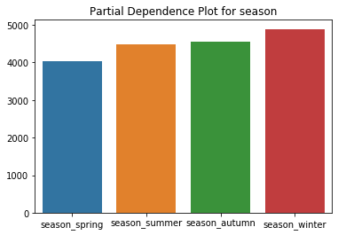

```python
ax = sns.barplot(x=PDs.index, y=PDs)
_ = ax.set_title('Partial Dependence Plot for season')
```

# Why are Partial Dependences so different from the group means?

This becomes clear once we compute ICEs, i.e. a PDP for *one* observation:

```python
# Compute group-by-season means of the predictions

data['yhat'] = rf_mod.predict(X)
print(data.groupby('season')['yhat'].mean())
data.drop('yhat', axis=1, inplace=True)
```

```
season
autumn    5638.569681
spring    2642.722099
summer    5013.737283
winter    4717.895787
Name: yhat, dtype: float64
```

```python
i = 234
one_obs = X.iloc[i:(i+1), :]  # weird syntax keeps it a DF instead of a Series

one_obs
```

| days_since_start | year | temp | feel_temp | humidity | windspeed | season_autumn | season_spring | season_summer | season_winter | holiday_no | ... | weekday_saturday | weekday_sunday | weekday_thursday | weekday_tuesday | weekday_wednesday | workingday_no | workingday_yes | weather_clear | weather_light rain | weather_mist |
| --- | --- | --- | --- | --- | --- | --- | --- | --- | --- | --- | --- | --- | --- | --- | --- | --- | --- | --- | --- | --- | --- |
| 234 | 2011 | 17.0 | 14.3 | 45.5 | 9.8 | 1 | 0 | 0 | 0 | 1 | ... | 0 | 0 | 0 | 1 | 0 | 0 | 1 | 1 | 0 | 0 |

1 rows × 23 columns

```python
seasons = ['season_spring', 'season_summer', 'season_autumn', 'season_winter']
PDs = pd.Series(np.nan, index=seasons)
for season in seasons:
    one_obs_temp = one_obs.copy()
    for S in seasons:
        one_obs_temp[S] = 0
    one_obs_temp[season] = 1
    PDs[season] = rf_mod.predict(one_obs_temp).mean()

# PD on 'season', *given* everything else (e.g. temperature) stays the same:
PDs
```

```
season_spring    4777.81
season_summer    5574.36
season_autumn    5641.54
season_winter    5612.98
dtype: float64
```

# PDPs of a linear model

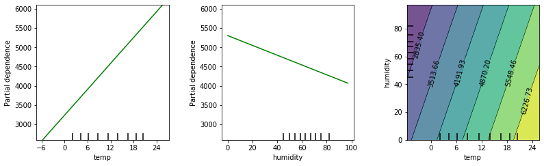

```python
from sklearn.inspection import partial_dependence, plot_partial_dependence  # needs sklearn >=0.21

# small vertical lines are the data's deciles

fig, ax = plt.subplots(1, 3, figsize=(12,5))

plot_partial_dependence(lm_mod, X, features=[1, 3, (1, 3)],
                       grid_resolution=25, percentiles=(0, 1), n_jobs=4,
                       feature_names=X.columns, fig=fig)
```

# PDPs of a Random Forest

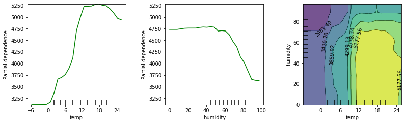

```python
fig, ax = plt.subplots(1, 3, figsize=(12,5))


plot_partial_dependence(rf_mod, X, features=[1, 3, (1, 3)],
                       grid_resolution=25, percentiles=(0, 1), n_jobs=4,
                       feature_names=X.columns, fig=fig)
```

### Recall problem 2: Understanding

PDPs are one solution to this problem because we obtain the marginalized feature effect for each feature.

# 3 - Shapley Values / SHAP

- How much does each feature contribute to a *single prediction*?
- "How to fairly distribute the prediction among the features?"
- For linear models, each feature's contribution is easy: $\beta_j \cdot x_j$
- Shapley values are based on game theory

https://christophm.github.io/interpretable-ml-book/shap.html  
https://github.com/slundberg/shap

```python
import shap

# explain the model's predictions using SHAP values
# (same syntax works for LightGBM, CatBoost, and scikit-learn models)
explainer = shap.TreeExplainer(rf_mod)

# Compute for only 100 observations to save computing time
X_sub = X.sample(100, random_state=20190818)

shap_values = explainer.shap_values(X_sub)  # takes long

# load JS visualization code to notebook
shap.initjs()
```

# Shapley Values

- Visualize Shapley Values as *forces*
- The Shapley values are *additive* importance measures
- They move the prediction away from the *base value* (the average prediction over all instances)

> "Why didn't we make any revenue on this day? It was a perfect 15°C!"

> "Yes, the temperature on that day was good for bike rentals, but that effect was nullified again by the high humidity"

```python
shap.force_plot(explainer.expected_value, shap_values[20,:], X_sub.iloc[20,:])
```

[output not shown]

### Recall problem 3: Explainability

- Shapley Values solve this problem because now you can visualize the size of each feature that contributed to a loan being rejected.

# Interpretation Methods

- As always, the answer to "which method?" is "it depends"
- What do you want to understand?
  - The *global* model behavior, or a *single* prediction?
  - The *importance* or the *effect size* of a feature?

# The Future of Interpretable Machine Learning

- ML will grow because it *automatizes* decision making
- IML helps:
  - to convince hesitant people or satisfy legal requirements
  - to understand the weaknesses in your models
- Model-agnostic methods are the most flexible
- Like ML, IML will be automatized in the future

[figure not shown]

- Twitter: @eng_elhardt
- Slides: https://github.com/AlexEngelhardt/iml-talk
- Longer blog post available at https://www.alpha-epsilon.de/blog/

# References

- Molnar, Christoph. "Interpretable machine learning. A Guide for Making Black Box Models Explainable", 2019. https://christophm.github.io/interpretable-ml-book/.
- Doshi-Velez, Finale, and Been Kim. “Towards a rigorous science of interpretable machine learning,” no. Ml: 1–13. http://arxiv.org/abs/1702.08608 (2017).
- Ribeiro, Marco Tulio, Sameer Singh, and Carlos Guestrin. "Model-agnostic interpretability of machine learning." https://arxiv.org/pdf/1606.05386 (2016).
- Biggio, Battista, and Fabio Roli. "Wild patterns: Ten years after the rise of adversarial machine learning." Pattern Recognition 84 (2018): 317-331. https://arxiv.org/pdf/1712.03141
- Athalye, Anish, et al. "Synthesizing robust adversarial examples." https://arxiv.org/pdf/1707.07397.pdf (2017).

# Bonus Slides

### IML on training or test data?

- tl;dr: It depends on what you want to know
- Imagine an overfitted SVM with 100 garbage features.
  - What feature importance would you expect?
    - Zero because the features are noise? $\Rightarrow$ use test data
    - Or should they reflect how much the model depends on each feature? $\Rightarrow$ use training data
- See also Molnar [chapter 5.5.2](https://christophm.github.io/interpretable-ml-book/feature-importance.html#feature-importance-data)

# Bonus Slides

### Correlations in features

- If features are correlated, partial dependence plots will be computed with unrealistic instances
- e.g. `temp = 20` degrees, but `feel_temp = -5`

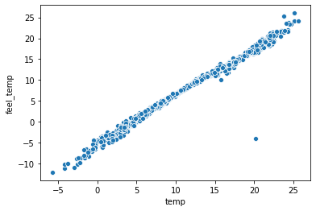

```python
sns.scatterplot('temp', 'feel_temp', data=data)
```

- wat do?
- A method called *Accumulated Local Effects* (ALEs) is unbiased then
- See Molnar 2019